# Lecture 20- Partial Pooling

Peter Shaffery

3/30/2021

# Example - Radon

Let’s say that you would like to buy a house in Minnesota. A big concern when buying a new house is checking its radon levels. Radon is a colorless, odorless gas produced as part of the radioactive decay process of Uranium. Prolonged exposure to radon can have serious (and negative) health consequences, so it’s important to buy a house without radon!

Fortunately you’ve got a dataset containing household level radon measurements all over Minnesota. Included in this dataset is the household’s county, the floor on which the measurement was made on, as well as some other potentially useful variable. You’d like to use this information to find a house with low radon levels.

```r
library(tidyverse)
library(magrittr)
library(lme4)

radon = read.csv('../../data/radon_mn.csv')
radon$log_radon = log(radon$activity+.001)

radon %>% head
```

```
##   idnum state state2 stfips   zip region typebldg floor room basement windoor
## 1  5081    MN     MN     27 55735      5        1     1    3        N      NA
## 2  5082    MN     MN     27 55748      5        1     0    4        Y      NA
## 3  5083    MN     MN     27 55748      5        1     0    4        Y      NA
## 4  5084    MN     MN     27 56469      5        1     0    4        Y      NA
## 5  5085    MN     MN     27 55011      3        1     0    4        Y      NA
## 6  5086    MN     MN     27 55014      3        1     0    4        Y      NA
##   rep stratum wave starttm stoptm startdt stopdt activity pcterr     adjwt
## 1   2       4   41     930    930   12088  12288      2.2    9.7 1146.4992
## 2   5       2   40    1615   1615   11888  12088      2.2   14.5  471.3662
## 3   3       2   42    1030   1515   20288  21188      2.9    9.6  433.3167
## 4   2       2   24    1410   1410  122987 123187      1.0   24.3  461.6237
## 5   3       2   40     600    600   12888  13088      3.1   13.8  433.3167
## 6   5       2   22     900   1300  120287 121187      2.5   12.8  471.3662
##   dupflag zipflag cntyfips county    log_radon
## 1       1       0        1 AITKIN 0.7889118025
## 2       0       0        1 AITKIN 0.7889118025
## 3       0       0        1 AITKIN 1.0650555051
## 4       0       0        1 AITKIN 0.0009995003
## 5       0       0        3  ANOKA 1.1317246401
## 6       0       0        3  ANOKA 0.9166906519
```

Recall from last lecture, our *varying-intercepts, partial-pooling* model:

$$\begin{split}
y_i &= \alpha_{j[i]} + \beta_1 x_i + \epsilon_i\\
\alpha_j& = \mu_{\alpha} + \eta_j\\
\end{split}$$
By relating the $\alpha_j$ to each other through the model $\alpha_j \sim N(\mu_{\alpha},\sigma^2_{\alpha})$ we allow the different counties to *share* information with each other, while also allowing for different counties to have different baseline log-radon.

Let’s fit that model

```r
partial = lmer(log_radon ~ floor + (1|county), data=radon)
```

Now, let’s say that in addition to our dataset containing household-level radon measurements we *also* have a dataset containing county-level data

```r
county = read.csv('../../data/county_radon.csv')
county %>% head
```

```
##   stfips ctfips st     cty     lon    lat    Uppm
## 1      1      1 AL AUTAUGA -86.643 32.534 1.78331
## 2      1      3 AL BALDWIN -87.750 30.661 1.38323
## 3      1      5 AL BARBOUR -85.393 31.870 2.10105
## 4      1      7 AL    BIBB -87.126 32.998 1.67313
## 5      1      9 AL  BLOUNT -86.568 33.981 1.88501
## 6      1     11 AL BULLOCK -85.716 32.100 2.46112
```

We see that, among other things, this dataset contains a measure of the county’s level of Uraniam (the column `Uppm`). Since radon is a product of uranium decay, we would expect a county’s overall uranium levels to be predictive of its radon baseline. Let’s combine this county data with our estimates $\hat \alpha_j$

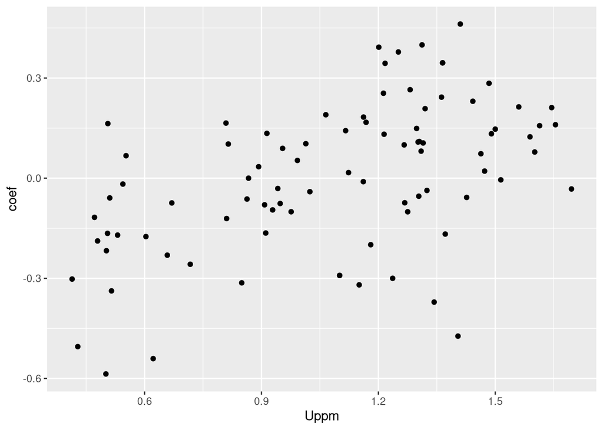

```r
plt.df = ranef(partial)$county
plt.df$county = plt.df %>% rownames
names(plt.df)=c('coef','cty')

plt.df %<>% left_join(county %>% filter(st=='MN'),by=c('cty'))

ggplot(plt.df, aes(x=Uppm,y=coef)) +
  geom_point()
```

```r
lm(coef ~ Uppm, data=plt.df) %>% summary
```

```
##
## Call:
## lm(formula = coef ~ Uppm, data = plt.df)
##
## Residuals:
##     Min      1Q  Median      3Q     Max
## -0.5772 -0.1066  0.0089  0.1315  0.3559
##
## Coefficients:
##             Estimate Std. Error t value Pr(>|t|)
## (Intercept) -0.35164    0.06785  -5.182 1.46e-06 ***
## Uppm         0.32442    0.05948   5.454 4.75e-07 ***
## ---
## Signif. codes:  0 '***' 0.001 '**' 0.01 '*' 0.05 '.' 0.1 ' ' 1
##
## Residual standard error: 0.1942 on 85 degrees of freedom
## Multiple R-squared:  0.2593, Adjusted R-squared:  0.2506
## F-statistic: 29.75 on 1 and 85 DF,  p-value: 4.747e-07
```

Clearly county UPPM predicts $\alpha_j$, the county’s baseline radon levels. Can we account for this relationship in our model? Yes!

$$\begin{split}
\text{LOG_RADON}_i &= \beta_0 + \beta_1 \text{FLOOR}_i + \sum_j \beta_{j[i]} \text{COUNTY}_{j[i]} + \epsilon_i\\
\beta_j &= \gamma_0 + \gamma_1 \text{UPPM}_j + \eta_j
\end{split}$$

Where $\eta_j \sim N(0, \sigma^2_{\beta})$

Fundamentally, this is not different than our partial pooling model $\alpha_j \sim N(\mu_{\alpha},\sigma^2_{\alpha})$. In both cases, we are simply specifying a linear model for the $\beta_j$, the only difference is in the mean of that model: $\mu_{\beta}$ vs $\gamma_0 + \gamma_1 \text{UPPM}_j + \eta_j$.

How can we interpret this model? One obvious way we have already seen, it simply relates the baseline log-radon to county-level features. But how is that different than just including UPPM as an independent variable in our log-radon regression?

Well, observe that we can plug the “upper” level of the model directly into the “lower” level:
$$\begin{split}
\text{LOG_RADON}_i &= \beta_0 + \beta_1 \text{FLOOR}_i + \sum_j (\gamma_0 + \gamma_1 \text{UPPM}_{j[i]} + \eta_{j[i]}) \text{ COUNTY}_{j[i]} + \epsilon_i\\
&= \beta_0' + \beta_1 \text{FLOOR}_i + \sum_j (\gamma_0 + \gamma_1 \text{UPPM}_{j[i]} + \eta_{j[i]}) \text{ COUNTY}_{j[i]} + \epsilon_i\\
\end{split}$$

Now, because $\text{ COUNTY}_{j[i]}$ is an indicator variable, only one term in that sum will end up in the final regression for any given $i$, hence we can just write this as:
$$y_i = \beta_0 + \beta_1 \text{FLOOR}_i + \gamma_0 + \gamma_1 \text{UPPM}_{j[i]} + \eta_{j[i]} + \epsilon_i$$

Combining up like terms:
$$\begin{split}
y_i &= (\beta_0 + \gamma_0) + \beta_1 \text{FLOOR}_i + \gamma_1 \text{UPPM}_{j[i]} + (\eta_{j[i]} + \epsilon_i)\\
&= \beta_0' + \beta_1 \text{FLOOR}_i + \beta_2 \text{UPPM}_i + \epsilon_i'\\
\end{split}$$
Now, this *looks* like the model that just plugs UPPM directly into the regression, but pay close attention to the error terms:
$$\epsilon_i' = \eta_{j[i]} + \epsilon_i$$
These error terms are not independent! Two error terms from the same county $j$ will share a $\eta_{j}$ factor. From this we can show a few interesting facts. First off, $\text{Var}[\epsilon_i] = \sigma^2_y + \sigma^2_{\beta}$. Second, we have that if $i$ and $k$ are the indices of two measurements from the same county (ie. $j[i]=j[k]$) then $\text{Cov}[\epsilon_i,\epsilon_k] = \sigma^2_{\beta}$. Finally, only if $i$ and $k$ correspond to measurements from *different* counties is $\text{Cov}[\epsilon_i,\epsilon_k] =0$.

Finally, finally, observe that there is one more way that we could write this (same) model:
$$\begin{split}
\text{LOG_RADON}_i &= \alpha_{j[i]} + \beta_1 \text{FLOOR}_i + \beta_2 \text{UPPM}_{j[i]} + \epsilon_i\\
\alpha_{j[i]} &= \gamma_0 + \eta_j
\end{split}$$
And observe that we could combine these two levels of the model together and obtain the same result as if we included UPPM in the “upper” level of the model instead. This final form is how `lmer` prefers county-level data to be incorporated:

```r
dat = radon %>% left_join(county,by=c('county'='cty'))
mod = lmer(log_radon ~ floor + Uppm + (1|county), data=dat)
summary(mod)
```

```
## Linear mixed model fit by REML ['lmerMod']
## Formula: log_radon ~ floor + Uppm + (1 | county)
##    Data: dat
##
## REML criterion at convergence: 8134.2
##
## Scaled residuals:
##     Min      1Q  Median      3Q     Max
## -9.2876 -0.6682  0.0262  0.6319  4.0129
##
## Random effects:
##  Groups   Name        Variance Std.Dev.
##  county   (Intercept) 0.1693   0.4115
##  Residual             0.5815   0.7626
## Number of obs: 3480, groups:  county, 85
##
## Fixed effects:
##             Estimate Std. Error t value
## (Intercept)  1.48645    0.06529  22.767
## floor       -0.93998    0.03941 -23.853
## Uppm         0.02440    0.02864   0.852
##
## Correlation of Fixed Effects:
##       (Intr) floor
## floor -0.128
## Uppm  -0.562  0.002
```

# When is Hierarchical Modeling/Partial Pooling Effective?

Typically hierarchical modeling is effective when pooling and non-pooling are *uneffective*. This sounds a little circular, but it’s the simplest heuristic. If $\sigma^2_{\beta}$ is small relative to $\sigma^2_y$ then there isn’t going to be much improvement over the pooled model. Conversely if $\sigma_{\beta}^2$ is much larger than $\sigma_y$ then the unpooled model will win out.

This leads us to the *intraclass correlation*: $\rho = \frac{\sigma_{\beta}^2}{(\sigma_{\beta}^2 + \sigma_y^2)}$. When $\rho$ is close to 0 then the grouping contains almost no information, and the hierarchical structure isn’t adding much to the model. On the other hand, when $\rho$ is close to 1 then within a grouping the $y_i$ will be very similar (setting aside differences due to the independent variables), and so an unpooled model may be more appropriate.

```r
summary(partial)
```

```
## Linear mixed model fit by REML ['lmerMod']
## Formula: log_radon ~ floor + (1 | county)
##    Data: radon
##
## REML criterion at convergence: 2295.4
##
## Scaled residuals:
##     Min      1Q  Median      3Q     Max
## -8.4712 -0.5262  0.0333  0.5716  3.3349
##
## Random effects:
##  Groups   Name        Variance Std.Dev.
##  county   (Intercept) 0.1077   0.3281
##  Residual             0.7422   0.8615
## Number of obs: 878, groups:  county, 85
##
## Fixed effects:
##             Estimate Std. Error t value
## (Intercept)  1.44336    0.05527   26.12
## floor       -0.76191    0.08255   -9.23
##
## Correlation of Fixed Effects:
##       (Intr)
## floor -0.305
```

## Can I Hypothesis Test the Hierarchical Structure?

Not really. Much like how it can be difficult to interpret the p-values of a one-hot encoded categorical variable with a large number of levels, p-values in the context of a hierachical model are challenging to make sense of. If only a small number of county-levels produce “significantly” non-zero $\hat \alpha_j$, does that mean that the county variable is an appropriate grouping-variable? It’s difficult to say.

Moreover, significance testing kind of misses the point. Typically in a hierarchical modeling scenario, we don’t really care whether St. Louis has significantly different log-radon levels than Lac Qui Parle. We’re using the model hierarchy to allow our model to control for county-county variability (or intra-group correlation) in a principled way.

## What Can I Use Instead?

We *do* still have ANOVA for models containing only categorical variables, deviance to compare nested models, and AIC for pretty much any case. All of these become more complex due to the hiearchical structure, however.

For one, it’s challenging to characterize the “number of parameters”, since we’ve allowed some parameters to be random. Instead define an “effective number of parameters” (or “effective degrees of freedom”), which is an estimate of how much pooling the model performs.

Typically it’s easiest to have these quantities computed using a package or just the `AIC` function from `stats`:

```r
pool = lm(log_radon~floor, data=radon)
unpool = lm(log_radon~floor+county, data=radon)
interact = lm(log_radon~floor*county, data=radon)
re = lmer(log_radon~floor + (1|county), data=radon)

AIC(pool,unpool,interact,re) %>% arrange(AIC)
```

```
##           df      AIC
## re         4 2303.399
## unpool    87 2316.784
## interact 145 2340.451
## pool       3 2348.828
```

# Hiearchical, Generalized, Linear Models

We can pretty straightforwardly extend the hiearchical modeling approach to the world of GLMs. Say that instead of working with log-radon, we converted the radon activity measurement to a “counts” scale and used a poisson regression instead:

```r
radon$activity_count = 10*radon$activity
mod = glmer(activity_count ~ floor + (1|county), data=radon, family=poisson)
summary(mod)
```

```
## Generalized linear mixed model fit by maximum likelihood (Laplace
##   Approximation) [glmerMod]
##  Family: poisson  ( log )
## Formula: activity_count ~ floor + (1 | county)
##    Data: radon
##
##      AIC      BIC   logLik deviance df.resid
##  24326.1  24340.5 -12160.1  24320.1      875
##
## Scaled residuals:
##    Min     1Q Median     3Q    Max
## -8.977 -3.176 -1.020  1.778 50.810
##
## Random effects:
##  Groups Name        Variance Std.Dev.
##  county (Intercept) 0.2079   0.456
## Number of obs: 878, groups:  county, 85
##
## Fixed effects:
##             Estimate Std. Error z value Pr(>|z|)
## (Intercept)  3.97675    0.05014   79.31   <2e-16 ***
## floor       -0.58897    0.01687  -34.91   <2e-16 ***
## ---
## Signif. codes:  0 '***' 0.001 '**' 0.01 '*' 0.05 '.' 0.1 ' ' 1
##
## Correlation of Fixed Effects:
##       (Intr)
## floor -0.050
```